# {samplyr}

A tidy grammar for survey sampling design

Ahmadou Dicko, PhD

The World Bank - UNHCR Joint Data Center on Forced Displacement | uRos 2026, Paris

## My first survey sample

**Fieldwork** I started out as a statistician in epidemiology. My first survey was a two-stage cluster survey, drawn in R with `{sampling}` and Tillé’s book beside me.

**One year later** When it was time to run the analysis, I had several versions of the script on disk and no way to tell which one had produced the sample. I computed the weights from the version I trusted most.

A year later, how do you know how your sample was actually drawn?

The stories in this talk are real, with the surveys and the statistical office kept unnamed.

## Our running example

We follow one synthetic survey modeled on the Gambia DHS across the rest of the talk.

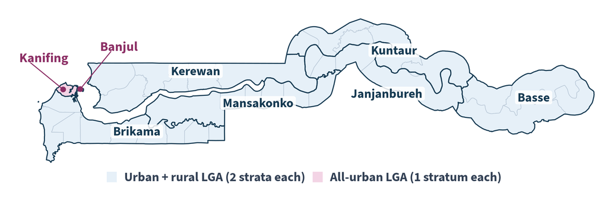

**Survey goal** Estimate modern contraceptive prevalence (`mCPR`) from household interviews.

**Sampling frame** 5,003 enumeration areas (311,113 households) across **8 LGAs** (`lga`), giving **14 strata**.

**One benchmark** Synthetic population and interviews so we can compare `{sampling}`, SPSS `CSPLAN`, and `{samplyr}` on one design.

## A two-stage cluster survey

Every household has a known selection probability, shaped by four practical constraints.

[figure not shown]

## The same design with `{sampling}`

Stage 1 In each of the 14 strata (8 LGAs by urban and rural), select clusters by systematic PPS on households, sorted by district and ward.

Stage 2 After listing each selected cluster, select **25 households** by systematic sampling.

Written the way I coded my first survey in `{sampling}`, the plan is split across two sorts, two `strata()` calls, and a manual merge for the weights.

```
## Stage 1, clusters
fr <- gmb_clusters
fr <- fr[order(fr$lga, fr$urban_rural,
               fr$district, fr$ward), ]
s1 <- strata(fr,
  stratanames = c("lga", "urban_rural"),
  size = gmb_alloc$n,
  method = "systematic", pik = fr$households)
psu <- getdata(fr, s1)

## Stage 2, households, after listing
li <- gmb_listing[order(gmb_listing$cluster), ]
s2 <- strata(li, stratanames = "cluster",
  size = rep(25, nrow(psu)),
  method = "systematic", pik = rep(1, nrow(li)))
hh <- getdata(li, s2)

## Weights
hh <- merge(hh, psu[, c("cluster", "Prob")],
  by = "cluster", suffixes = c("_2", "_1"))
hh$weight <- 1 / (hh$Prob_1 * hh$Prob_2)
```

## A meeting in West Africa

Stage 1 In each of the 14 strata (8 LGAs by urban and rural), select clusters by systematic PPS on households, sorted by district and ward.

Stage 2 After listing each selected cluster, select **25 households** by systematic sampling.

I went to recommend R to a statistical office, and they showed me SPSS `CSPLAN`. Rewritten for our Gambia example, it keeps the whole plan in one file.

```
CSPLAN SAMPLE
  /PLAN FILE='gambia_survey.csplan'
  /DESIGN STAGELABEL='Clusters'
    STRATA=lga urban_rural
    CLUSTER=cluster
  /METHOD TYPE=PPS_SYSTEMATIC
  /MOS VARIABLE=households
  /SIZE MATRIX=lga urban_rural;
    'Banjul' 'Urban' 34;
    'Basse' 'Rural' 39; /* 12 more rows */
  /DESIGN STAGELABEL='Households'
  /METHOD TYPE=SIMPLE_SYSTEMATIC
  /SIZE VALUE=25.
```

Can R code read as clearly as the sampling report?

## The same design with `{samplyr}`

Stage 1 In each of the 14 strata (8 LGAs by urban and rural), select clusters by systematic PPS on households, sorted by district and ward.

Stage 2 After listing each selected cluster, select **25 households** by systematic sampling.

No separate weight calculation. `execute()` computes the weights directly from the design.

```
gmb_design <-
  sampling_design("Gambia survey") |>
  add_stage("Clusters") |>
    stratify_by(lga, urban_rural) |>
    cluster_by(cluster) |>
    draw(n = gmb_alloc,
      method = "pps_systematic",
      mos = households,
      control = c(district, ward)) |>
  add_stage("Households") |>
    draw(n = 25,
      method = "systematic")
```

Write the design once. Then check the frame, run each stage, and archive the draw.

## The design is an object

```r
gmb_design
```

```
── Sampling Design: Gambia survey ────────

ℹ 2 stages

── Stage 1: Clusters ─────────────────────
• Strata: lga, urban_rural
• Cluster: cluster
• Draw: n = <custom data frame, per stratum>, method = pps_systematic, mos = households, control = c(district, ward)

── Stage 2: Households ───────────────────
• Draw: n = 25 (per cluster), method = systematic
```

```r
gmb_alloc
```

```
# A tibble: 14 × 3
  lga    urban_rural     n
  <chr>  <chr>       <dbl>
1 Banjul Urban          34
2 Basse  Rural          39
3 Basse  Urban          17
# ℹ 11 more rows
```

`gmb_design` defines the full plan before loading any frame, so it can be versioned and reviewed on its own.

`gmb_alloc` holds cluster sample sizes from `{svyplan}` and matches strata by name, not row order.

## Check the frame before fieldwork

Each row in `gmb_clusters` is one enumeration area (EA). Banjul, the capital, is entirely urban.

```
# A tibble: 5,003 × 7
  lga    urban_rural cluster district       ward  households   eas
  <chr>  <chr>       <chr>   <chr>          <chr>      <int> <int>
1 Banjul Urban       1021001 Banjul Central New …         81     1
2 Banjul Urban       1021002 Banjul Central New …         55     1
# ℹ 5,001 more rows
```

Suppose a recoding mistake marks Banjul EAs as rural.

```r
bad_frame <- mutate(gmb_clusters,
  urban_rural = if_else(lga == "Banjul", "Rural", urban_rural))
validate_frame(gmb_design, bad_frame, stages = 1)
```

```
Error in `validate_frame()`:
! `n` names 1 stratum that stage 1 "Clusters" does not have.
✖ No unit the stage can reach is in "Banjul/Urban".
ℹ Check the labels against lga and urban_rural in the frame, or drop the entries.
```

## Run each stage on the field schedule

**January** Select 307 clusters for field listing and archive a receipt

**April** Field listings return, select 25 households per cluster

```r
## January
selected <- execute(gmb_design, gmb_clusters, stages = 1, seed = 2025)
write_design(selected, receipt_file, frame = gmb_clusters)

## April
issued <- execute(selected, gmb_listing, seed = 2027)
```

```
# A tbl_sample: 7675 × 13 | Gambia survey
# Sampling:     2 stages | 7,675 units
# Weights:      40.54 [7.76, 112.57]
  lga    urban_rural cluster hh_id households .weight .sample_id
* <chr>  <chr>       <chr>   <int>      <int>   <dbl>      <int>
1 Banjul Urban       1011002    79         76    7.76          1
2 Banjul Urban       1011002    82         76    7.76          2
# ℹ 7,673 more rows
```

`issued` keeps the design metadata alongside the combined two-stage weights.

## Pass the sample to `{srvyr}`

```r
issued |>
  left_join(gmb_interviews, by = "hh_id") |>
  as_survey_design(stages = 1, systematic_variance = "approximate") |>
  summarize(mcpr = survey_ratio(users, married, vartype = "ci"))
```

```
# A tibble: 1 × 3
   mcpr mcpr_low mcpr_upp
  <dbl>    <dbl>    <dbl>
1 0.172    0.158    0.185
```

Strata, clusters, weights, and finite population corrections pass straight to `{srvyr}`, or to `{survey}` via `as_svydesign()`.

Modern contraceptive prevalence is **17.2%** (15.8% to 18.5%, 95% CI) on simulated interviews.

These are base design weights, ready for nonresponse adjustment and calibration.

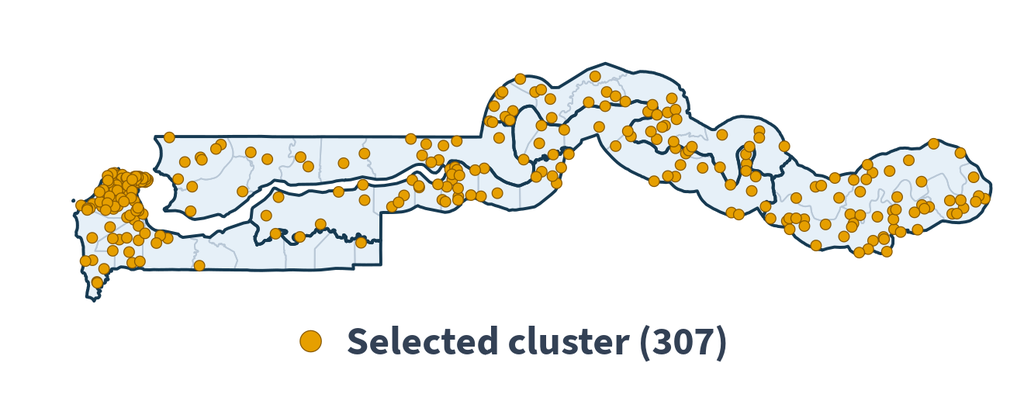

## Back to my first survey

```
{
  "design": { "title": "Gambia survey",
    "stages": [{
      "label": "Clusters",
      "strata": { "vars": ["lga", "urban_rural"] },
      "clusters": { "vars": ["cluster"] },
      "draw": {
        "method": { "id": "systematic_probability_proportional_to_size",
          "standards": [{ "vocabulary": "DDI SamplingProcedure",
                          "code": "Probability" }] },
        "mos": "households", ... } },
      { "label": "Households", ... }] },
  "execution": {
    "seed": 2025, "n_selected": 307,
    "frame_digest": { "n_rows": 5003, "fingerprint_exact": "60a0483377..." } },
  "tools": { "samplyr": { "version": "0.9.999", ... } }
}
```

```r
again <- replay_design(read_design(receipt_file), gmb_clusters)
```

```
replay identical: TRUE
```

A year later, anyone can reproduce the exact January draw from this receipt. If the frame has changed, `replay_design()` stops with an error.

## Back to that meeting

| In the report | SAS `PROC SURVEYSELECT` | SPSS `CSPLAN` | `{samplyr}` |
| --- | --- | --- | --- |
| Strata | `STRATA` | `STRATA=` | `stratify_by()` |
| Clusters | `CLUSTER` | `CLUSTER=` | `cluster_by()` |
| Systematic PPS | `METHOD=PPS_SYS` | `TYPE=PPS_SYSTEMATIC` | `draw(method = "pps_systematic")` |
| Measure of size | `SIZE` | `/MOS` | `draw(mos = households)` |
| Sizes by stratum | `SAMPSIZE=` data set | `/SIZE MATRIX=` | `draw(n = gmb_alloc)` |
| Sort order | `CONTROL` | no keyword | `draw(control = c(...))` |
| Next stage | a new `PROC` | a new `/DESIGN` | `add_stage()` |

The keywords map directly from SAS and SPSS, and `{samplyr}` adds frame validation, multi-stage weights, receipts, and direct `{survey}` integration.

## Take-aways

**How do you know how your sample was drawn?** The sample keeps its design and weights, and `write_design()` archives a receipt to audit and replay the draw.

**Can R code read as clearly as the report?** One pipeline expresses strata, clusters, stages, and selection methods in the same order as the sampling appendix.

Write the design once. Then check the frame, run each stage, and archive the draw.

**Three places to start**

- Write the sampling appendix of your next survey round as a `sampling_design()`
- Translate one `PROC SURVEYSELECT` or `CSPLAN` program keyword by keyword
- Archive an existing survey draw with `write_design()` for handover or audit

## Thank you

Documentation at [dickoa.gitlab.io/samplyr](https://dickoa.gitlab.io/samplyr/)

```r
pak::pkg_install("gitlab::dickoa/samplyr")
```

Contact at `mail@ahmadoudicko.com`

**Also supported** Rotating panels, spatial and balanced sampling, certainty units, permanent random numbers, reserve lists, and replicate weights.

Questions?

[figure not shown]

Scan for docs and install